# Weight liting modelling

Marcin Kruczyk

Saturday, October 24, 2015

## Loading data

The data has been delivered in the form of .csv files. *pml-training.csv* is the file containing data for training and *pml-testing.csv* contains data for testing. In the testing file there are no lables, so it can not be used to estimate quality of the model. Therefore *validation set* will be created in order to estimate parameters of the model.

```r
library(caret)
training <- read.csv("./pml-training.csv")
testing <- read.csv("./pml-testing.csv")
set.seed(348)
inTrain <- createDataPartition(training$classe, p=0.7, list=FALSE)
validation <- training[-inTrain,]
training <- training[inTrain,]
```

## Exploration Analysis

First let’s take a look at the training data.

```r
dim(training)
```

```
## [1] 13737   160
```

```r
nnas <- apply(training, 2, function(x) sum(is.na(x)))
nnas[nnas > 0]
```

```
##            max_roll_belt           max_picth_belt            min_roll_belt
##                    13447                    13447                    13447
##           min_pitch_belt      amplitude_roll_belt     amplitude_pitch_belt
##                    13447                    13447                    13447
##     var_total_accel_belt            avg_roll_belt         stddev_roll_belt
##                    13447                    13447                    13447
##            var_roll_belt           avg_pitch_belt        stddev_pitch_belt
##                    13447                    13447                    13447
##           var_pitch_belt             avg_yaw_belt          stddev_yaw_belt
##                    13447                    13447                    13447
##             var_yaw_belt            var_accel_arm             avg_roll_arm
##                    13447                    13447                    13447
##          stddev_roll_arm             var_roll_arm            avg_pitch_arm
##                    13447                    13447                    13447
##         stddev_pitch_arm            var_pitch_arm              avg_yaw_arm
##                    13447                    13447                    13447
##           stddev_yaw_arm              var_yaw_arm             max_roll_arm
##                    13447                    13447                    13447
##            max_picth_arm              max_yaw_arm             min_roll_arm
##                    13447                    13447                    13447
##            min_pitch_arm              min_yaw_arm       amplitude_roll_arm
##                    13447                    13447                    13447
##      amplitude_pitch_arm        amplitude_yaw_arm        max_roll_dumbbell
##                    13447                    13447                    13447
##       max_picth_dumbbell        min_roll_dumbbell       min_pitch_dumbbell
##                    13447                    13447                    13447
##  amplitude_roll_dumbbell amplitude_pitch_dumbbell       var_accel_dumbbell
##                    13447                    13447                    13447
##        avg_roll_dumbbell     stddev_roll_dumbbell        var_roll_dumbbell
##                    13447                    13447                    13447
##       avg_pitch_dumbbell    stddev_pitch_dumbbell       var_pitch_dumbbell
##                    13447                    13447                    13447
##         avg_yaw_dumbbell      stddev_yaw_dumbbell         var_yaw_dumbbell
##                    13447                    13447                    13447
##         max_roll_forearm        max_picth_forearm         min_roll_forearm
##                    13447                    13447                    13447
##        min_pitch_forearm   amplitude_roll_forearm  amplitude_pitch_forearm
##                    13447                    13447                    13447
##        var_accel_forearm         avg_roll_forearm      stddev_roll_forearm
##                    13447                    13447                    13447
##         var_roll_forearm        avg_pitch_forearm     stddev_pitch_forearm
##                    13447                    13447                    13447
##        var_pitch_forearm          avg_yaw_forearm       stddev_yaw_forearm
##                    13447                    13447                    13447
##          var_yaw_forearm
##                    13447
```

There are a lot of variables with very high number of NA’s. I decided to remove from the data every variable with number of NA’s higher than 5000.

```r
nas <- NULL
for(i in 1:ncol(training)){
        nas <- c(nas, sum(is.na(training[,i])))
}
nas_index <- nas < 5000
training <- training[,nas_index]
testing <- testing[,nas_index[-length(nas_index)]]
validation <- validation[,nas_index[-length(nas_index)]]
summary(training)
```

```
##        X            user_name    raw_timestamp_part_1 raw_timestamp_part_2
##  Min.   :    1   adelmo  :2765   Min.   :1.322e+09    Min.   :   301
##  1st Qu.: 4900   carlitos:2173   1st Qu.:1.323e+09    1st Qu.:254787
##  Median : 9818   charles :2501   Median :1.323e+09    Median :500319
##  Mean   : 9811   eurico  :2128   Mean   :1.323e+09    Mean   :501947
##  3rd Qu.:14720   jeremy  :2359   3rd Qu.:1.323e+09    3rd Qu.:750669
##  Max.   :19622   pedro   :1811   Max.   :1.323e+09    Max.   :998801
##
##           cvtd_timestamp new_window    num_window      roll_belt
##  05/12/2011 11:24:1047   no :13447   Min.   :  1.0   Min.   :-28.90
##  28/11/2011 14:14:1035   yes:  290   1st Qu.:220.0   1st Qu.:  1.10
##  30/11/2011 17:11: 991               Median :424.0   Median :114.00
##  05/12/2011 11:25: 989               Mean   :430.7   Mean   : 64.88
##  02/12/2011 13:34: 985               3rd Qu.:645.0   3rd Qu.:123.00
##  05/12/2011 14:23: 979               Max.   :864.0   Max.   :162.00
##  (Other)         :7711
##    pitch_belt          yaw_belt       total_accel_belt kurtosis_roll_belt
##  Min.   :-55.8000   Min.   :-180.00   Min.   : 1.00             :13447
##  1st Qu.:  1.6300   1st Qu.: -88.30   1st Qu.: 3.00    #DIV/0!  :    6
##  Median :  5.2700   Median : -11.80   Median :17.00    -1.908453:    2
##  Mean   :  0.1538   Mean   : -10.28   Mean   :11.37    -0.016850:    1
##  3rd Qu.: 14.8000   3rd Qu.:  14.50   3rd Qu.:18.00    -0.021024:    1
##  Max.   : 60.3000   Max.   : 179.00   Max.   :29.00    -0.025513:    1
##                                                        (Other)  :  279
##  kurtosis_picth_belt kurtosis_yaw_belt skewness_roll_belt
##           :13447            :13447              :13447
##  #DIV/0!  :   23     #DIV/0!:  290     #DIV/0!  :    6
##  -1.851307:    3                       0.000000 :    4
##  1.326417 :    3                       0.422463 :    2
##  2.777851 :    3                       -0.015465:    1
##  47.000000:    3                       -0.024325:    1
##  (Other)  :  255                       (Other)  :  276
##  skewness_roll_belt.1 skewness_yaw_belt  max_yaw_belt    min_yaw_belt
##           :13447             :13447            :13447          :13447
##  #DIV/0!  :   23      #DIV/0!:  290     -1.4   :   24   -1.4   :   24
##  -2.156553:    3                        -1.1   :   20   -1.1   :   20
##  -0.475418:    2                        -1.2   :   19   -1.2   :   19
##  -0.733570:    2                        -0.7   :   16   -0.7   :   16
##  -1.362688:    2                        -0.9   :   16   -0.9   :   16
##  (Other)  :  258                        (Other):  195   (Other):  195
```

[output cut: 153 more lines]

```
##  Min.   :-498.00   Min.   :-632.0   Min.   :-410.00   Min.   :-1280.0
##  1st Qu.:-178.00   1st Qu.:  57.0   1st Qu.:-182.00   1st Qu.: -614.0
##  Median : -57.00   Median : 201.0   Median : -39.00   Median : -380.0
##  Mean   : -62.11   Mean   : 163.9   Mean   : -55.13   Mean   : -311.6
##  3rd Qu.:  76.00   3rd Qu.: 313.0   3rd Qu.:  25.00   3rd Qu.:  -76.0
##  Max.   : 477.00   Max.   : 923.0   Max.   : 291.00   Max.   :  672.0
##
##  magnet_forearm_y magnet_forearm_z classe
##  Min.   :-892.0   Min.   :-966.0   A:3906
##  1st Qu.:  -3.0   1st Qu.: 194.0   B:2658
##  Median : 591.0   Median : 511.0   C:2396
##  Mean   : 377.6   Mean   : 395.9   D:2252
##  3rd Qu.: 737.0   3rd Qu.: 653.0   E:2525
##  Max.   :1480.0   Max.   :1090.0
##
```

There are also a lot of variables which have empty cells and *DIV/0!* string. I decided to replace those values with NA’s and repeat the procedure of discarding variables with high number of NA’s.

```r
for(i in 1:ncol(training)){
        training[training[,i] == "#DIV/0!" | training[,i] == "", i] <- NA
}

nas <- NULL
for(i in 1:ncol(training)){
        nas <- c(nas, sum(is.na(training[,i])))
}
nas_index <- nas < 5000
training <- training[,nas_index]
testing <- testing[,nas_index[-length(nas_index)]]
validation <- validation[,nas_index[-length(nas_index)]]
dim(training)
```

```
## [1] 13737    60
```

```r
colnames(training)
```

```
##  [1] "X"                    "user_name"            "raw_timestamp_part_1"
##  [4] "raw_timestamp_part_2" "cvtd_timestamp"       "new_window"
##  [7] "num_window"           "roll_belt"            "pitch_belt"
## [10] "yaw_belt"             "total_accel_belt"     "gyros_belt_x"
## [13] "gyros_belt_y"         "gyros_belt_z"         "accel_belt_x"
## [16] "accel_belt_y"         "accel_belt_z"         "magnet_belt_x"
## [19] "magnet_belt_y"        "magnet_belt_z"        "roll_arm"
## [22] "pitch_arm"            "yaw_arm"              "total_accel_arm"
## [25] "gyros_arm_x"          "gyros_arm_y"          "gyros_arm_z"
## [28] "accel_arm_x"          "accel_arm_y"          "accel_arm_z"
## [31] "magnet_arm_x"         "magnet_arm_y"         "magnet_arm_z"
## [34] "roll_dumbbell"        "pitch_dumbbell"       "yaw_dumbbell"
## [37] "total_accel_dumbbell" "gyros_dumbbell_x"     "gyros_dumbbell_y"
## [40] "gyros_dumbbell_z"     "accel_dumbbell_x"     "accel_dumbbell_y"
## [43] "accel_dumbbell_z"     "magnet_dumbbell_x"    "magnet_dumbbell_y"
## [46] "magnet_dumbbell_z"    "roll_forearm"         "pitch_forearm"
## [49] "yaw_forearm"          "total_accel_forearm"  "gyros_forearm_x"
## [52] "gyros_forearm_y"      "gyros_forearm_z"      "accel_forearm_x"
## [55] "accel_forearm_y"      "accel_forearm_z"      "magnet_forearm_x"
## [58] "magnet_forearm_y"     "magnet_forearm_z"     "classe"
```

Now let’s take a look at the timestamp variables. They should not carry any information about the decision, so probably those variables, index variable named *X* and *new_window* variable should be discarded. Just in case let’s take a look at the timestamp variables versus decision variable.

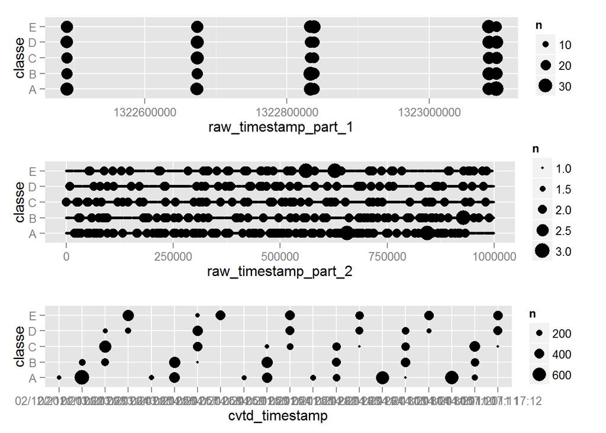

```r
library(ggplot2)
library(grid)
library(gridExtra)
p1 <- ggplot(data=training, aes(raw_timestamp_part_1, classe)) + stat_sum(aes(size=..n..))
p2 <- ggplot(data=training, aes(raw_timestamp_part_2, classe)) + stat_sum(aes(size=..n..))
p3 <- ggplot(data=training, aes(cvtd_timestamp, classe)) + stat_sum(aes(size=..n..))
grid.arrange(p1, p2, p3, ncol=1)
```

```r
training <- training[, -c(1, 3, 4, 5, 6)]
testing <- testing[, -c(1, 3, 4, 5, 6)]
validation <- validation[, -c(1, 3, 4, 5, 6)]
dim(training)
```

```
## [1] 13737    55
```

```r
colnames(training)
```

```
##  [1] "user_name"            "num_window"           "roll_belt"
##  [4] "pitch_belt"           "yaw_belt"             "total_accel_belt"
##  [7] "gyros_belt_x"         "gyros_belt_y"         "gyros_belt_z"
## [10] "accel_belt_x"         "accel_belt_y"         "accel_belt_z"
## [13] "magnet_belt_x"        "magnet_belt_y"        "magnet_belt_z"
## [16] "roll_arm"             "pitch_arm"            "yaw_arm"
## [19] "total_accel_arm"      "gyros_arm_x"          "gyros_arm_y"
## [22] "gyros_arm_z"          "accel_arm_x"          "accel_arm_y"
## [25] "accel_arm_z"          "magnet_arm_x"         "magnet_arm_y"
## [28] "magnet_arm_z"         "roll_dumbbell"        "pitch_dumbbell"
## [31] "yaw_dumbbell"         "total_accel_dumbbell" "gyros_dumbbell_x"
## [34] "gyros_dumbbell_y"     "gyros_dumbbell_z"     "accel_dumbbell_x"
## [37] "accel_dumbbell_y"     "accel_dumbbell_z"     "magnet_dumbbell_x"
## [40] "magnet_dumbbell_y"    "magnet_dumbbell_z"    "roll_forearm"
## [43] "pitch_forearm"        "yaw_forearm"          "total_accel_forearm"
## [46] "gyros_forearm_x"      "gyros_forearm_y"      "gyros_forearm_z"
## [49] "accel_forearm_x"      "accel_forearm_y"      "accel_forearm_z"
## [52] "magnet_forearm_x"     "magnet_forearm_y"     "magnet_forearm_z"
## [55] "classe"
```

There are factor variables in the data so it makes sense to create dummy variables. Let’s do it.

```r
decision <- training$classe
decision_val <- validation$classe

training <- model.matrix(classe~., data=training)[,-1]
testing <- model.matrix(~., data=testing)[,-1]
validation <- model.matrix(~., data=validation[,-ncol(validation)])[,-1]
dim(training)
```

```
## [1] 13737    58
```

Now we will remove the variables which have zero or near zero variance. They would not have large impact on the quality of the model.

```r
nzv <- nearZeroVar(training, saveMetrics= TRUE)
sum(nzv$nzv)
```

```
## [1] 0
```

There are no variables with low variance in the dataset, so there is nothing to discard. Now we will filter variables which are highly correlated. We will discard variables which have correlation > 0.75. Of course one variable from each group of the correlated variables will be kept.

```r
descrCor <- cor(training)
summary(descrCor[upper.tri(descrCor)])
```

```
##       Min.    1st Qu.     Median       Mean    3rd Qu.       Max.
## -0.9920000 -0.1201000  0.0007817 -0.0017750  0.0964200  0.9808000
```

```r
highlyCorDescr <- findCorrelation(descrCor, cutoff = .75)
training <- training[,-highlyCorDescr]
testing <- testing[,-highlyCorDescr]
validation <- validation[,-highlyCorDescr]
descrCor2 <- cor(training)
summary(descrCor2[upper.tri(descrCor2)])
```

```
##      Min.   1st Qu.    Median      Mean   3rd Qu.      Max.
## -0.680100 -0.118000  0.004262 -0.003105  0.093930  0.747700
```

```r
dim(training)
```

```
## [1] 13737    35
```

Now let’s find linear combinations in the data and let’s discard the redundant variables.

```r
findLinearCombos(training)
```

```
## $linearCombos
## list()
##
## $remove
## NULL
```

```r
dim(training)
```

```
## [1] 13737    35
```

There are no variables in linear combinations so we do not need to remove anything. Now we will apply recursive feature selection (RFE) algorithm to select variables that are necessary for solving our classification problem. The method is computationally complex so we will try finding a set of variables from 1 to 25. If it appears to be to few, we will try with more variables.

```r
training <-  as.data.frame(training)
training$classe <- decision
validation <- as.data.frame(validation)
validation$classe <- decision_val
colnames(training)
```

```
##  [1] "user_namecarlitos"    "user_namecharles"     "user_namejeremy"
##  [4] "num_window"           "yaw_belt"             "gyros_belt_x"
##  [7] "gyros_belt_y"         "gyros_belt_z"         "magnet_belt_x"
## [10] "magnet_belt_y"        "roll_arm"             "pitch_arm"
## [13] "yaw_arm"              "total_accel_arm"      "gyros_arm_y"
## [16] "gyros_arm_z"          "accel_arm_y"          "accel_arm_z"
## [19] "magnet_arm_x"         "roll_dumbbell"        "pitch_dumbbell"
## [22] "yaw_dumbbell"         "total_accel_dumbbell" "gyros_dumbbell_y"
## [25] "roll_forearm"         "pitch_forearm"        "yaw_forearm"
## [28] "total_accel_forearm"  "gyros_forearm_x"      "gyros_forearm_z"
## [31] "accel_forearm_x"      "accel_forearm_z"      "magnet_forearm_x"
## [34] "magnet_forearm_y"     "magnet_forearm_z"     "classe"
```

```r
dim(training)
```

```
## [1] 13737    36
```

```r
set.seed(415)
ctrl <- rfeControl(functions=rfFuncs, method="cv", number=5, verbose=TRUE)

rfeMod <- rfe(training[,-36],training[,36], metric = "Accuracy",
              size=c(1:25), rfeControl = ctrl)
```

```r
rfeMod
```

```
##
## Recursive feature selection
##
## Outer resampling method: Cross-Validated (5 fold)
##
## Resampling performance over subset size:
##
##  Variables Accuracy  Kappa AccuracySD   KappaSD Selected
##          1   0.8282 0.7816  0.2347254 0.2984758
##          2   0.9965 0.9956  0.0013516 0.0017095
##          3   0.9950 0.9936  0.0017902 0.0022642
##          4   0.9975 0.9968  0.0016476 0.0020837        *
##          5   0.9964 0.9955  0.0014417 0.0018235
##          6   0.9956 0.9945  0.0011778 0.0014897
##          7   0.9957 0.9946  0.0015731 0.0019894
```

[output cut: 22 more lines]

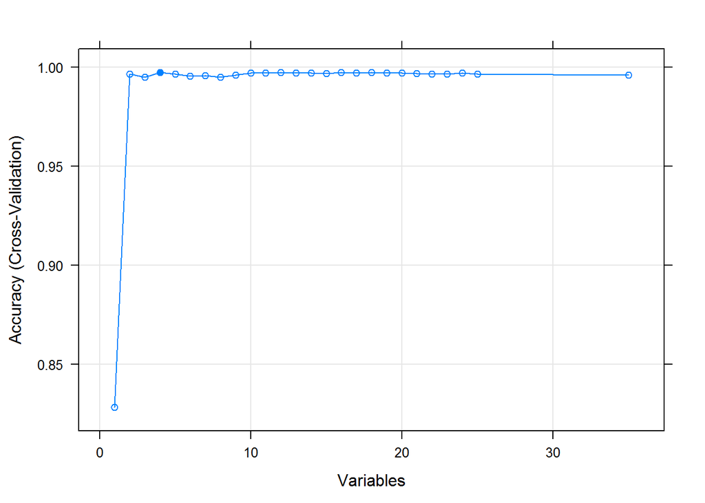

```r
plot(rfeMod, type=c("g","o"))
```

According to the algorithm the optimal number of variables to be used for the model are 4, but one can see, that there is no large difference between including 2 and 4 variables. However we will trust the algorithm and will include the 4 variables for further processing.

```r
indexes <- c(which(colnames(training) %in% rfeMod$optVariables), 36)
training <- training[, indexes]
testing <- testing[, indexes]
validation <- validation[, indexes]
colnames(training)
```

```
## [1] "num_window"    "yaw_belt"      "magnet_belt_y" "roll_dumbbell"
## [5] "classe"
```

The important variables are: *num_window*, *yaw_belt*, *magnet_belt_y* and *roll_dumbbell*. Let’s plot the 4 selected variables against each other and the decision.

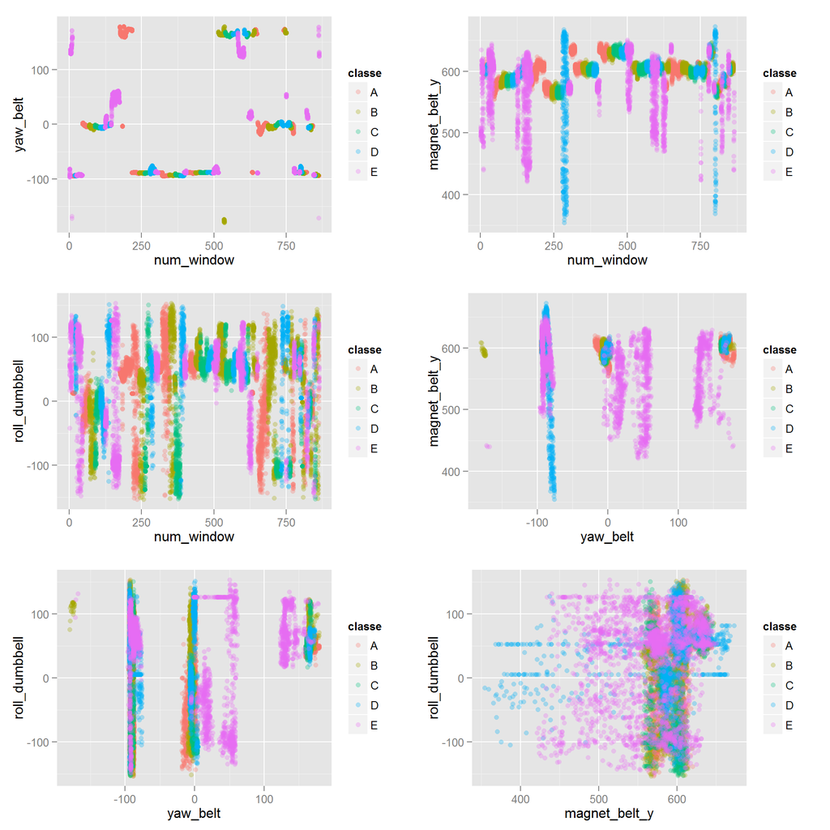

```r
p1 <- ggplot(data=training, aes(x=num_window, y=yaw_belt, color=classe))
p1 <- p1 + geom_point(alpha=0.3)
p2 <- ggplot(data=training, aes(x=num_window, y=magnet_belt_y, color=classe))
p2 <- p2 + geom_point(alpha=0.3)
p3 <- ggplot(data=training, aes(x=num_window, y=roll_dumbbell, color=classe))
p3 <- p3 + geom_point(alpha=0.3)
p4 <- ggplot(data=training, aes(x=yaw_belt, y=magnet_belt_y, color=classe))
p4 <- p4 + geom_point(alpha=0.3)
p5 <- ggplot(data=training, aes(x=yaw_belt, y=roll_dumbbell, color=classe))
p5 <- p5 + geom_point(alpha=0.3)
p6 <- ggplot(data=training, aes(x=magnet_belt_y, y=roll_dumbbell, color=classe))
p6 <- p6 + geom_point(alpha=0.3)
grid.arrange(p1, p2, p3, p4, p5, p6, ncol=2)
```

There is no clear pattern in the plots.

## Building Model

The problem is classification problem. I decided to use Random Forest algorithm to build the model. This time the full interpretability of the model is not necessary and Random Forest is very effective algorithm. I use repeated corss-validation to avoid overfitting. I will also try to choose the optimal value of *mtry* parameter. Usually the optimal value is $\sqrt{number of features}$ but just in case let’s optimize the parameter.

```r
ctrl <- trainControl(method = "repeatedcv",
                     number=5,
                     repeats = 5,
                     classProbs = TRUE,
                     summaryFunction = multiClassSummary
)


forestGrid <- expand.grid(mtry = c(1:4))


set.seed(123)
modFit <- train(classe ~ .,
                data = training,
                method = "rf",
                tuneGrid = forestGrid,
                trControl = ctrl,
                ntree=100
)
modFit
```

```
## Random Forest
##
## 13737 samples
##     4 predictor
##     5 classes: 'A', 'B', 'C', 'D', 'E'
##
## No pre-processing
## Resampling: Cross-Validated (5 fold, repeated 5 times)
## Summary of sample sizes: 10990, 10989, 10990, 10989, 10990, 10990, ...
## Resampling results across tuning parameters:
##
##   mtry  logLoss     Mean_ROC  Accuracy   Kappa      Mean_Sensitivity
##   1     0.12226196  NaN       0.9886439  0.9856366  0.9878640
##   2     0.03669970  NaN       0.9972192  0.9964828  0.9969719
##   3     0.02134958  NaN       0.9974230  0.9967406  0.9972207
##   4     0.02236592  NaN       0.9957050  0.9945674  0.9953144
##   Mean_Specificity  Mean_Pos_Pred_Value  Mean_Neg_Pred_Value
##   0.9971727         0.9879661            0.9971777
##   0.9993155         0.9969512            0.9993140
##   0.9993627         0.9972113            0.9993624
##   0.9989368         0.9953610            0.9989423
##   Mean_Detection_Rate  Mean_Balanced_Accuracy  logLoss SD   Accuracy SD
##   0.1977288            0.9925184               0.005472768  0.002698580
##   0.1994438            0.9981437               0.002770356  0.001377520
##   0.1994846            0.9982917               0.002422212  0.001086530
##   0.1991410            0.9971256               0.008341160  0.001497165
##   Kappa SD     Mean_Sensitivity SD  Mean_Specificity SD
##   0.003412530  0.002805120          0.0006681958
##   0.001742423  0.001568154          0.0003395380
##   0.001374432  0.001198893          0.0002757775
##   0.001894028  0.001636609          0.0003812606
##   Mean_Pos_Pred_Value SD  Mean_Neg_Pred_Value SD  Mean_Detection_Rate SD
##   0.002923501             0.0006790084            0.0005397160
##   0.001514985             0.0003345976            0.0002755040
##   0.001100597             0.0002675636            0.0002173060
##   0.001499848             0.0003690422            0.0002994331
##   Mean_Balanced_Accuracy SD
##   0.0017344293
##   0.0009531193
##   0.0007362256
##   0.0010078573
##
## Accuracy was used to select the optimal model using  the largest value.
## The final value used for the model was mtry = 3.
```

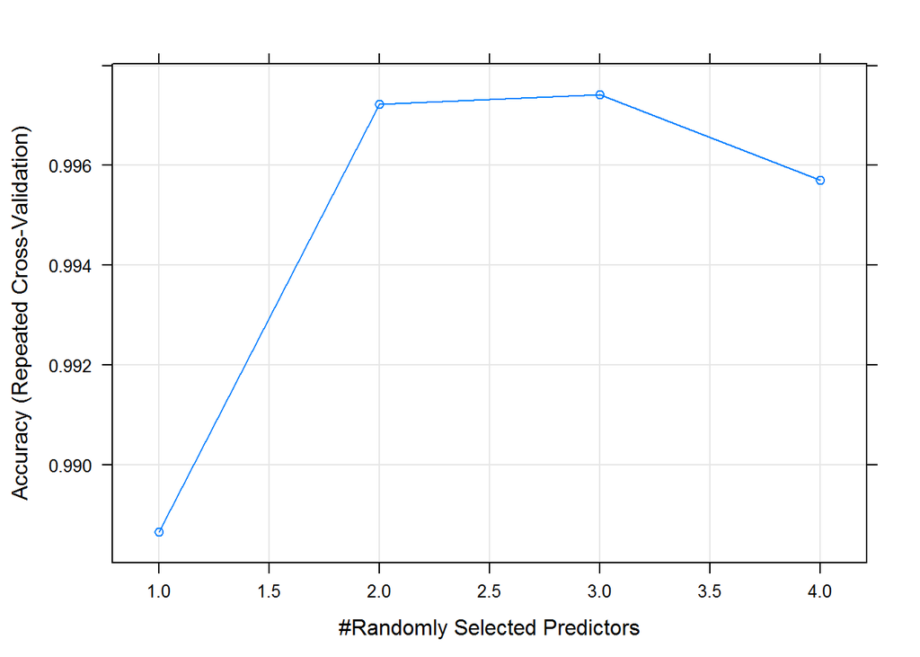

```r
plot(modFit)
```

Suprisingly, the model has the best Accuracy and other quality measures like logLoss and Kappa for mtry=3. The Accuracy over 99% is an excellent result. Now we need to see if the model is not overfitted.

## Model Validation

I will use the final model produced by *caret* to predict the classes from the validation dataset.

```r
library(randomForest)
val_pred <- predict(modFit$finalModel, newdata=validation)
confusionMatrix(val_pred, decision_val)
```

```
## Confusion Matrix and Statistics
##
##           Reference
## Prediction    A    B    C    D    E
##          A 1673    1    0    0    0
##          B    1 1137    2    0    0
##          C    0    1 1022    0    0
##          D    0    0    2  962    0
##          E    0    0    0    2 1082
##
## Overall Statistics
##
##                Accuracy : 0.9985
##                  95% CI : (0.9971, 0.9993)
##     No Information Rate : 0.2845
##     P-Value [Acc > NIR] : < 2.2e-16
##
##                   Kappa : 0.9981
##  Mcnemar's Test P-Value : NA
##
## Statistics by Class:
##
##                      Class: A Class: B Class: C Class: D Class: E
## Sensitivity            0.9994   0.9982   0.9961   0.9979   1.0000
## Specificity            0.9998   0.9994   0.9998   0.9996   0.9996
## Pos Pred Value         0.9994   0.9974   0.9990   0.9979   0.9982
## Neg Pred Value         0.9998   0.9996   0.9992   0.9996   1.0000
## Prevalence             0.2845   0.1935   0.1743   0.1638   0.1839
## Detection Rate         0.2843   0.1932   0.1737   0.1635   0.1839
## Detection Prevalence   0.2845   0.1937   0.1738   0.1638   0.1842
## Balanced Accuracy      0.9996   0.9988   0.9979   0.9988   0.9998
```

The Accuracy of the model on the validation dataset is also over 99% which means the model is not overfitted and has a very high quality.

## Prediction

Finally, I use the model to predict values from the imported dataset.

```r
predict(modFit$finalModel, newdata=testing)
```

```
##  1  2  3  4  5  6  7  8  9 10 11 12 13 14 15 16 17 18 19 20
##  B  A  B  A  A  E  D  B  A  A  B  C  B  A  E  E  A  B  B  B
## Levels: A B C D E
```